# Project Report

## Data Preparation

### Loading Data

```python
import pandas as pd
import seaborn as sns
from scipy import stats
import matplotlib.pyplot as plt
import numpy as np
```

```python
DF = pd.read_csv('bikes.data.txt')
```

```python
DF.head(10)
```

|  | ticket | cost | month | location_from | location_to | duration | distance | assistance | energy_used | energy_collected |
| --- | --- | --- | --- | --- | --- | --- | --- | --- | --- | --- |
| 0 | season | 0.00 | 7 | TEATTERI | TEATTERI | 3 | 0 | 0 | 0.0 | 0.0 |
| 1 | single | 0.35 | 7 | TORI | TEATTERI | 416 | 820 | 1 | 7.5 | 0.6 |
| 2 | season | 0.00 | 8 | TORI | SATAMA | 721 | 1230 | 0 | 0.0 | 2.1 |
| 3 | single | 0.25 | 5 | TEATTERI | TORI | 261 | 720 | 0 | 0.0 | 1.2 |
| 4 | season | 0.00 | 5 | TEATTERI | TORI | 382 | 710 | 1 | 3.3 | 0.9 |
| 5 | season | 0.00 | 8 | MICROTEKNIA | TEATTERI | 960 | 2670 | 1 | 21.5 | 6.3 |
| 6 | season | 0.00 | 6 | RYPYSUO | KYS | 589 | 3130 | 1 | 25.9 | 11.4 |
| 7 | season | 0.00 | 5 | SATAMA | TORI | 1276 | 4870 | 1 | 50.3 | 8.4 |
| 8 | season | 0.00 | 8 | SATAMA | SATAMA | 72 | 0 | 1 | 0.0 | 0.0 |
| 9 | season | 0.00 | 9 | TEATTERI | VÄINÖLÄNNIEMI | 1090 | 5010 | 1 | 44.0 | 8.1 |

Categorical => ticket, month, location_from, location_to, assistance

Quantitative => cost, duration, distance, energy_used, energy_collected

```python
categorical = ['ticket', 'month', 'location_from', 'location_to', 'assistance']
quantitative = ['cost', 'duration', 'distance', 'energy_used', 'energy_collected']
for var in categorical:
    DF[var] = pd.Categorical(DF[var])
```

### Data Description and Basic statistics

```python
DF.info()
```

```
<class 'pandas.core.frame.DataFrame'>
RangeIndex: 2000 entries, 0 to 1999
Data columns (total 10 columns):
 #   Column            Non-Null Count  Dtype
---  ------            --------------  -----
 0   ticket            2000 non-null   category
 1   cost              2000 non-null   float64
 2   month             2000 non-null   category
 3   location_from     2000 non-null   category
 4   location_to       2000 non-null   category
 5   duration          2000 non-null   int64
 6   distance          2000 non-null   int64
 7   assistance        2000 non-null   category
 8   energy_used       2000 non-null   float64
 9   energy_collected  2000 non-null   float64
dtypes: category(5), float64(3), int64(2)
memory usage: 89.4 KB
```

There are no null values in the data.

##### Description of quantitative variables

```python
DF[quantitative].describe()
```

|  | cost | duration | distance | energy_used | energy_collected |
| --- | --- | --- | --- | --- | --- |
| count | 2000.00000 | 2000.000000 | 2000.00000 | 2000.000000 | 2000.000000 |
| mean | 0.22345 | 539.975500 | 1721.93000 | 11.761300 | 4.389300 |
| std | 0.47570 | 593.810888 | 2017.79918 | 15.573439 | 5.990604 |
| min | 0.00000 | 1.000000 | -3320.00000 | 0.000000 | 0.000000 |
| 25% | 0.00000 | 144.750000 | 40.00000 | 0.000000 | 0.000000 |
| 50% | 0.00000 | 400.000000 | 1130.00000 | 7.100000 | 2.400000 |
| 75% | 0.30000 | 736.750000 | 2572.50000 | 18.500000 | 6.900000 |
| max | 6.95000 | 8292.000000 | 19740.00000 | 184.300000 | 91.500000 |

Distance column has negative value, which is not possible

```python
DF.loc[DF.distance < 0, ['distance']]
```

|  | distance |
| --- | --- |
| 457 | -90 |
| 537 | -30 |
| 567 | -20 |
| 689 | -40 |
| 801 | -110 |
| 996 | -3320 |
| 1244 | -1340 |
| 1347 | -30 |
| 1674 | -10 |
| 1683 | -20 |
| 1839 | -20 |

Only 11 rows have negative distance, therefore we can either drop them, consider absolute value or consider them to be 0. I have replaced the negative distance with 0.

```python
#DF.drop(DF.loc[DF.distance < 0, 'distance'].index, inplace=True)
DF.loc[DF.distance < 0, 'distance'] = 0
```

##### Description of categorical variables

```python
DF[categorical].describe()
```

|  | ticket | month | location_from | location_to | assistance |
| --- | --- | --- | --- | --- | --- |
| count | 2000 | 2000 | 2000 | 2000 | 2000 |
| unique | 3 | 7 | 10 | 10 | 2 |
| top | season | 6 | TORI | TORI | 1 |
| freq | 893 | 488 | 673 | 756 | 1633 |

##### Visualization of quantative variables

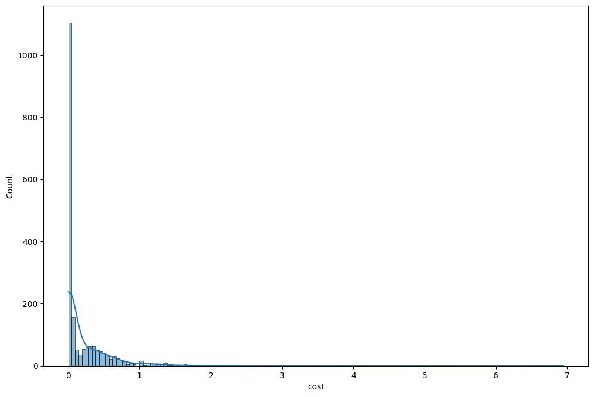

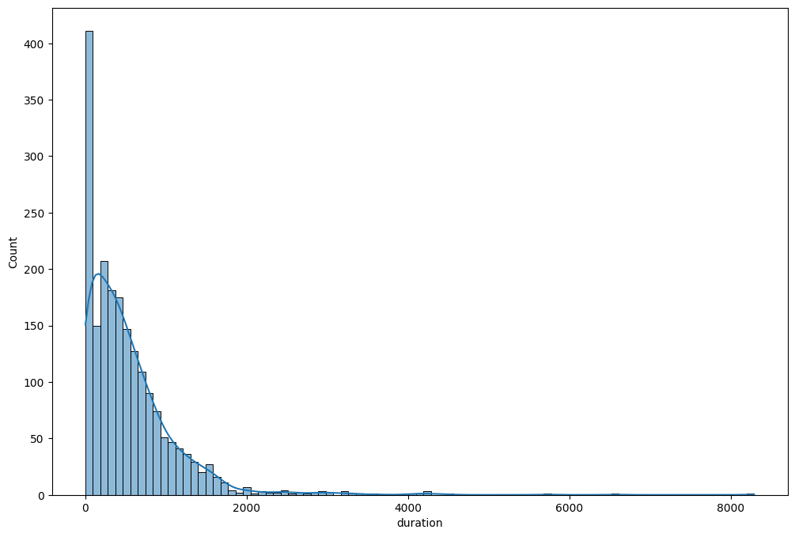

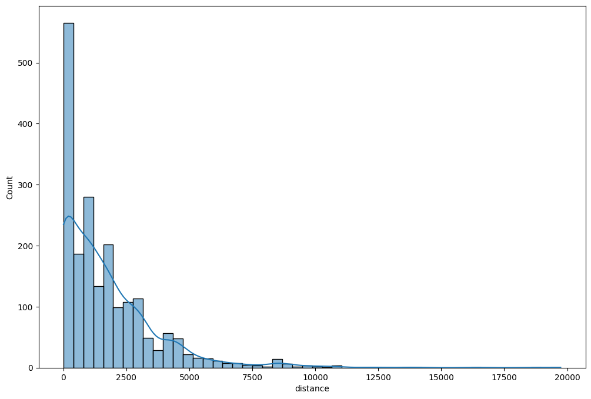

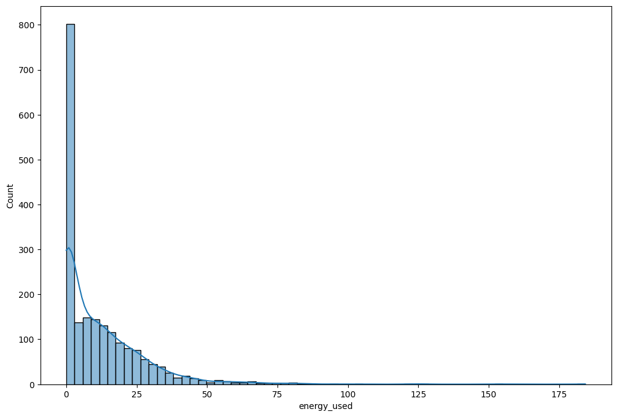

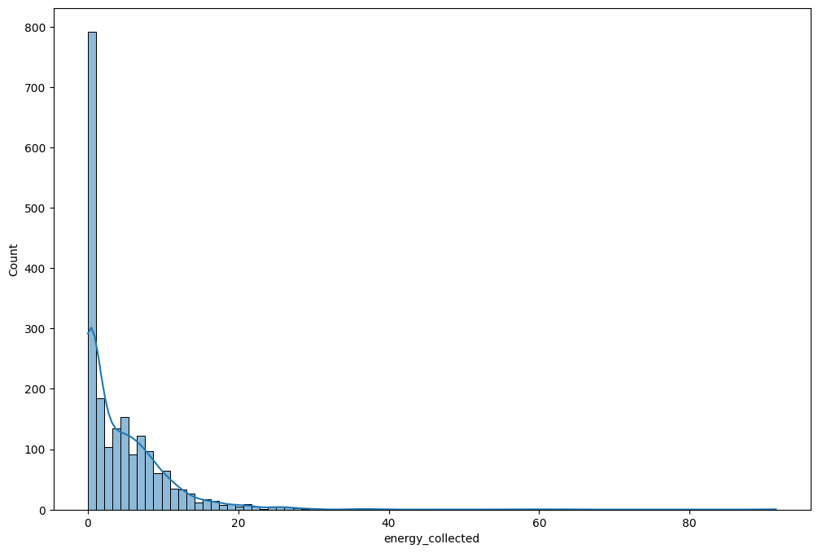

```python
for variable in quantitative:
    plt.figure()
    plt.tight_layout()
    fig, ax = plt.subplots(figsize=(12, 8))
    sns.histplot(data=DF, x=variable, kde=True, ax=ax)
```

##### Visualization of categorical variables

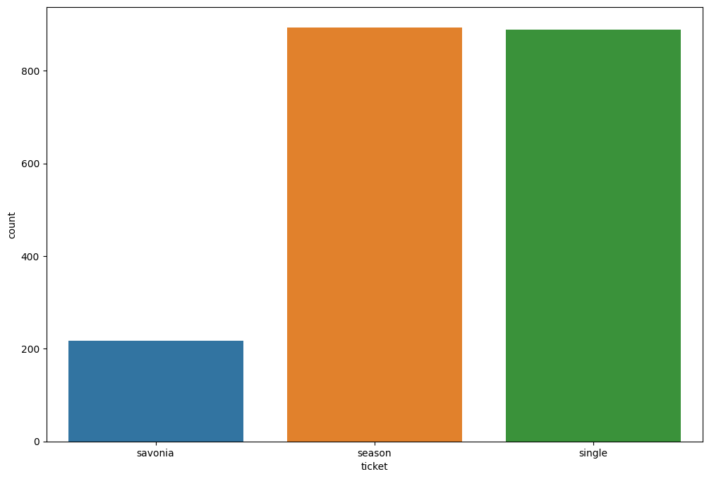

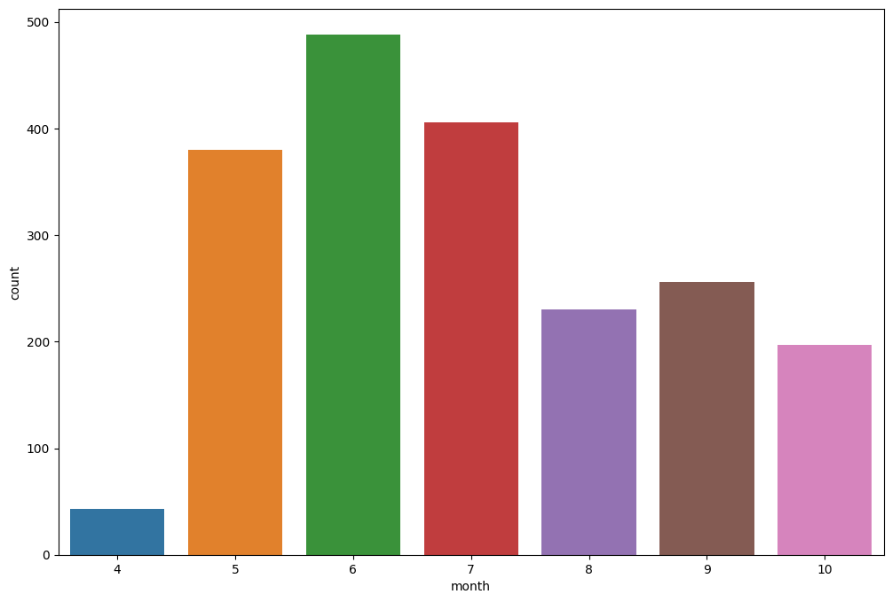

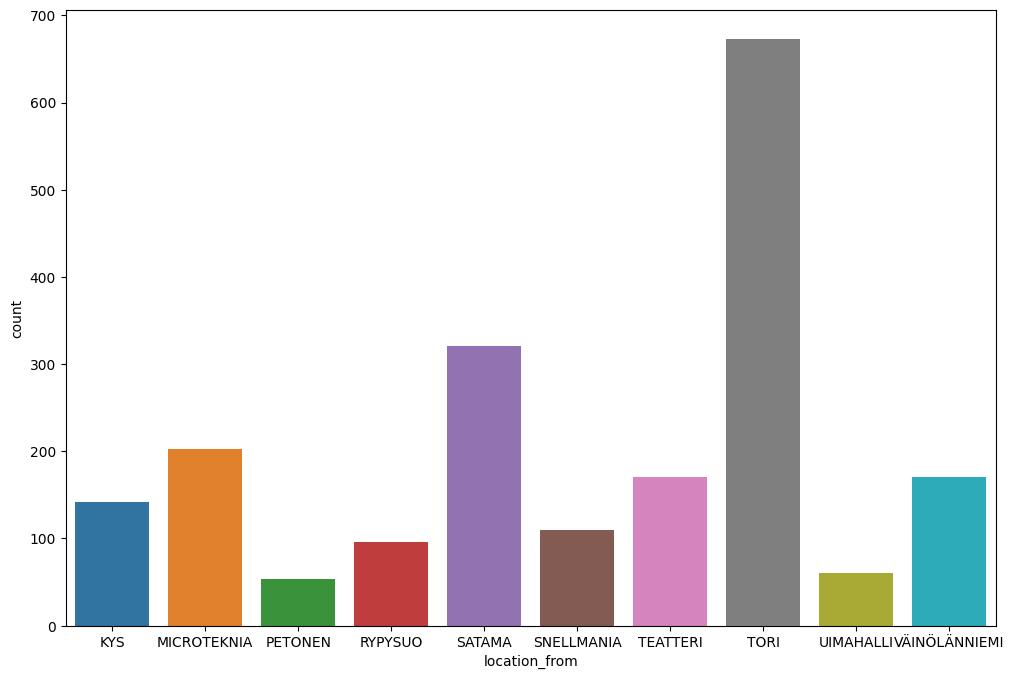

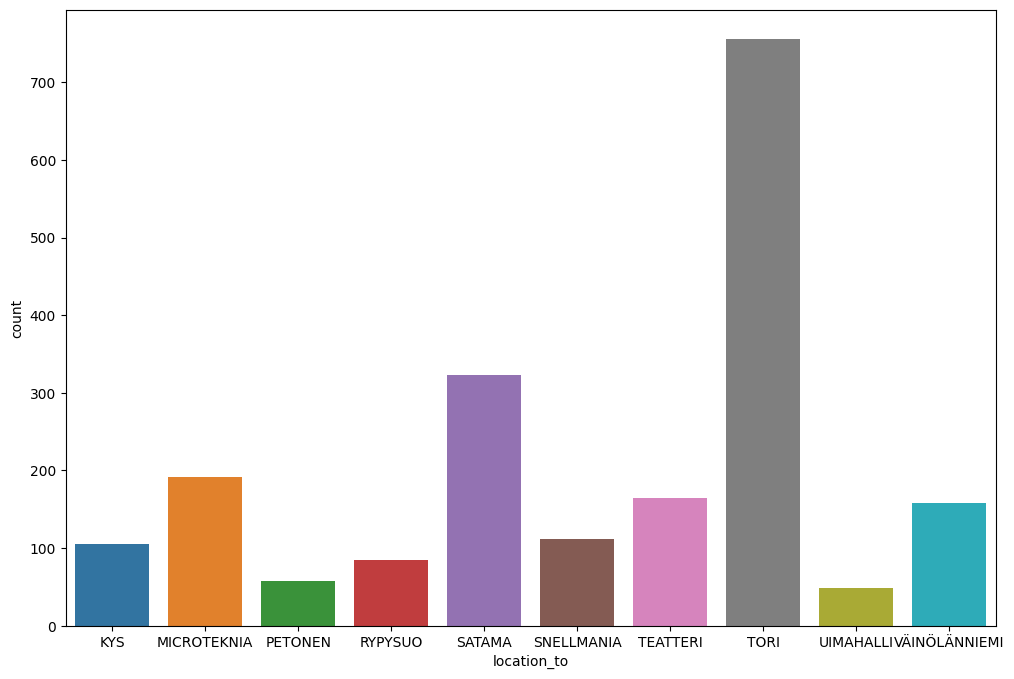

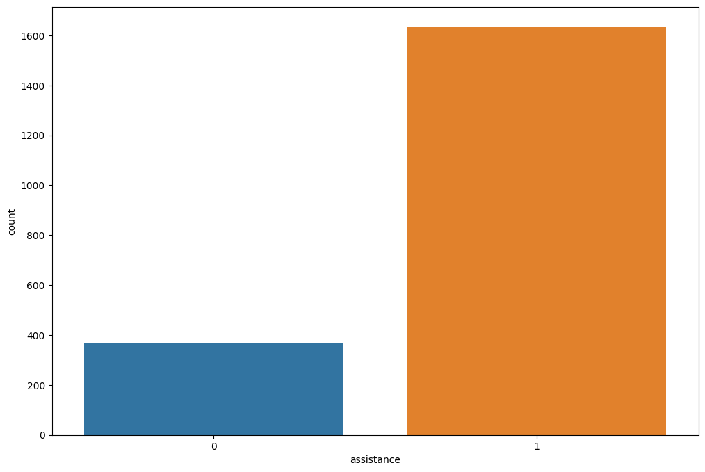

```python
for variable in categorical:
    plt.figure()
    plt.tight_layout()
    fig, ax = plt.subplots(figsize=(12, 8))
    sns.countplot(data=DF, x=variable, ax=ax)
```

## Data Exploration

##### 1. Total distance travelled, the total time travelled, and the total amount of fees paid per ticket type.

```python
DF_groupedby_ticket = DF.groupby('ticket')
DF_groupedby_ticket[['distance','duration','cost']].sum()
```

| ticket | distance | duration | cost |
| --- | --- | --- | --- |
| savonia | 408580 | 122618 | 0.0 |
| season | 1419140 | 459643 | 8.0 |
| single | 1621170 | 497690 | 438.9 |

##### 2. The mean distance travelled, the mean energy consumed, and the mean energy collected per status of assistance.

```python
DF_groupedby_assistance = DF.groupby('assistance')
DF_groupedby_assistance[['distance','energy_used','energy_collected']].mean()
```

| assistance | distance | energy_used | energy_collected |
| --- | --- | --- | --- |
| 0 | 873.542234 | 0.000000 | 1.661853 |
| 1 | 1915.676669 | 14.404532 | 5.002266 |

##### 3. The three most popular locations per ticket type in terms of the number of trips that either started or ended at the location.

```python
for name, grp in DF_groupedby_ticket:
    print("-----",name,"-----")
    count = grp.location_from.value_counts() + grp.location_to.value_counts()
    print(count.sort_values(ascending=False).head(3), end='\n\n')
```

```
----- savonia -----
MICROTEKNIA    140
TORI           127
SNELLMANIA      44
dtype: int64

----- season -----
TORI             631
SATAMA           288
VÄINÖLÄNNIEMI    164
dtype: int64

----- single -----
TORI        671
SATAMA      314
TEATTERI    159
dtype: int64
```

The three most popular locations are as follows:

savonia => MICROTEKNIA [140 trips], TORI [127 trips], SNELLMANIA [44 trips]

season => TORI [631 trips], SATAMA [288 trips], VÄINÖLÄNNIEMI [164 trips]

single => TORI [671 trips], SATAMA [314 trips], TEATTERI [159 trips]

##### 4. Visualization of monthly rental activity per ticket type in terms of total distance travelled

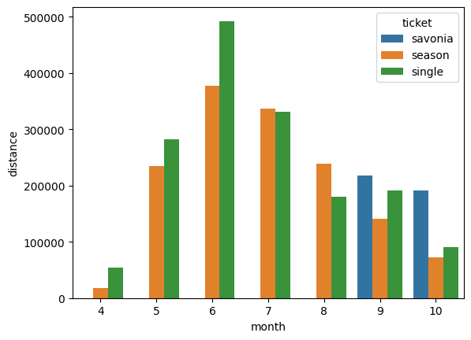

```python
data = DF.groupby(['ticket','month'])['distance'].sum().reset_index()
sns.barplot(data=data, x='month', y='distance', hue='ticket')
```

##### 5. Visualization the distribution of net energy gain

```python
DF['net_energy_gain'] = DF.energy_collected - DF.energy_used
```

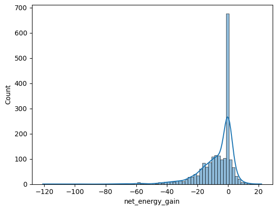

```python
sns.histplot(data=DF, x='net_energy_gain', kde=True)
```

##### 6. Visualization of the pairwise relationships between the quantitative variables.

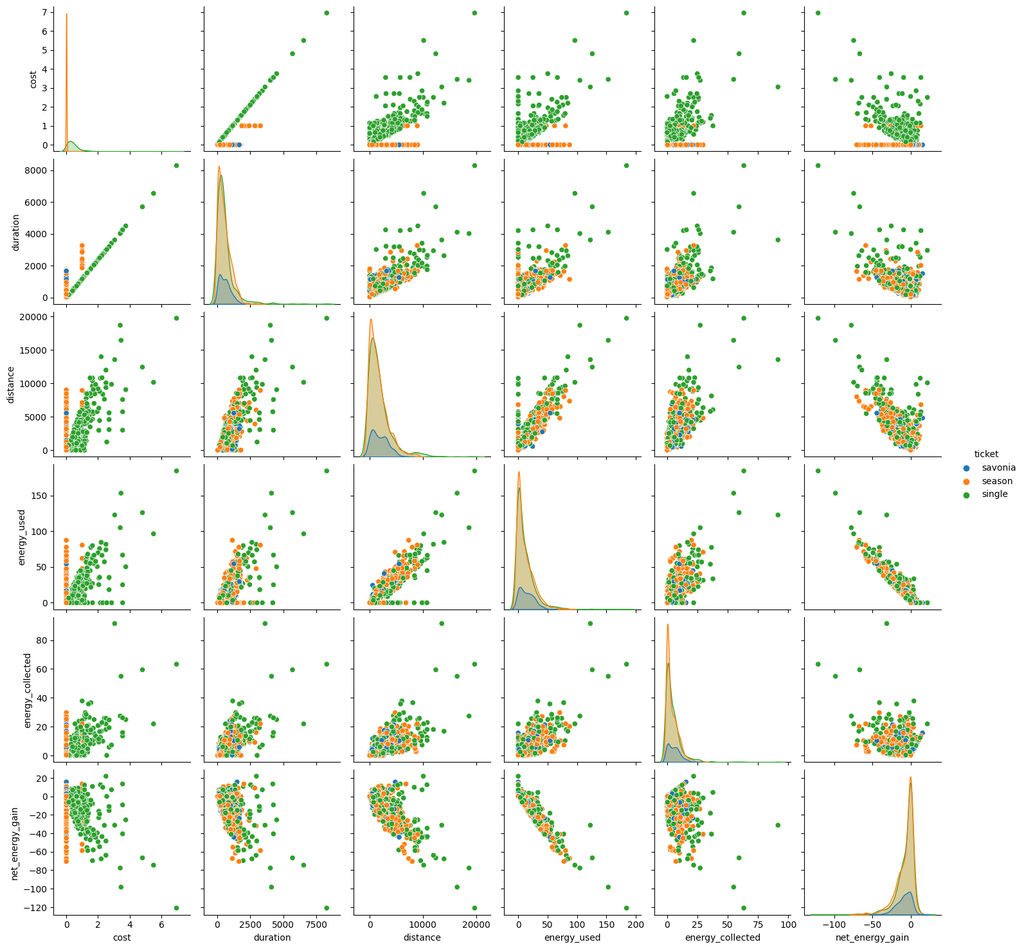

```python
sns.pairplot(DF,hue='ticket')
```

[figure not shown]

```python
sns.heatmap(DF.corr(), annot=True)
```

## Hypothesis testing

##### 1. What the p-value of a statistical test means and how it can be used to make conclusions.

Whenever we run statistical tests we get corresponding p-values. A statistical test compares two possible hypotheses. The p-value is used to express the statistical significance, it is the probability value and is used to either accept or reject the null hypothesis. p-value is number between 0 and 1. We compare the p-value with alpha (aka significance level). The alpha value is defined by the domain expert, if not given, it is generally considered to be 0.05. If the p-value that we derive is smaller than the alpha, it implies that it is statistically significant (indicating strong evidence against the null hypothesis) and we reject the null hypothesis. On the other hand, if p-value is larger than the alpha, we fail to reject (or accept) the null hypothesis.

##### 2. Statistical evidence to claim that the travel times tend to be shorter or longer for the single than for the season ticket type

```python
# Function to check if data is normally distributed or not
def normal_distribution(data):
    p_value = stats.shapiro(data).pvalue
    if p_value <= 0.05:
        return False
    else:
        return True
```

```python
single_ticket = DF_groupedby_ticket.get_group('single')
season_ticket = DF_groupedby_ticket.get_group('season')
savonia_ticket = DF_groupedby_ticket.get_group('savonia')
```

```python
print(normal_distribution(single_ticket.duration))
print(normal_distribution(season_ticket.duration))
```

```
False
False
```

```python
stats.mannwhitneyu(single_ticket.duration,season_ticket.duration)
```

```
MannwhitneyuResult(statistic=387090.5, pvalue=0.3645632872998459)
```

##### **Steps**

- Check if the variables are quantitative or categorical (quantitative in this case)
- Check if the variables are normally distributed or not using Shapiro Wilk test (not normally distributed in this case)
- Next step is to compare the means and standard deviations of the sample (using Mann–Whitney U test, as the two variables are quantative, independent and not normally distributed)

**p-value of Mann–Whitney U test (0.3645632872998459) > 0.05, therefore, there is no significant difference between the travel times for the single and the season ticket type.**

##### 3. Statistical evidence to claim that the single and savonia ticket types differ with respect to how often the electric assistance is used

```python
assistance_contigency = pd.crosstab(DF.loc[(DF.ticket == 'single') | (DF.ticket == 'savonia'), 'ticket'], DF.assistance)
assistance_contigency
```

| assistance ticket | 0 | 1 |
| --- | --- | --- |
| savonia | 9 | 209 |
| single | 191 | 698 |

```python
stats.chi2_contingency(assistance_contigency)[1]
```

```
4.3404376688598015e-09
```

##### **Steps**

- Check the variable type (categorical in this case).
- No need to check normality, since the variables are categorical.
- Next step is to compare the two groups using chi square test, as the two variables are categorical.

**p-value of the chi square test (4.3404376688598015e-09) < 0.05, therefore, there is statistically significant difference between electric assistance used by the two ticket types.**

##### 4. Statistical evidence to claim that the travel distances tend to be shorter or longer during one month than during the others

```python
DF_groupby_month = DF.groupby(DF.month)['distance']
```

```python
DF_groupby_month.apply(lambda grp: normal_distribution(grp))
```

```
month
4     False
5     False
6     False
7     False
8     False
9     False
10    False
Name: distance, dtype: bool
```

```python
stats.kruskal(*[group.values for name, group in DF_groupby_month])
```

```
KruskalResult(statistic=53.47034775442593, pvalue=9.43316676101914e-10)
```

##### **Steps**

- Check the variable type (numerical in this case).
- Check if the variables are normally distributed or not using Shapiro Wilk test (not normally distributed in this case)
- Next step is to compare the difference between the sample (using Kruskal–Wallis test, as all the variables are quantative, independent and not normally distributed)

**p-value of the Kruskal–Wallis test (9.43316676101914e-10) < 0.05, therefore, there is statistically significant difference between distance travelled among all the months.**

##### 5. Statistical evidence to claim that the distance travelled correlates with the energy consumed when the electric assistance is enabled.

```python
distance_energy_used_correlation = DF.loc[DF.assistance == 1 , ['distance','energy_used']].corr(method='spearman')
distance_energy_used_correlation
```

|  | distance | energy_used |
| --- | --- | --- |
| distance | 1.000000 | 0.947479 |
| energy_used | 0.947479 | 1.000000 |

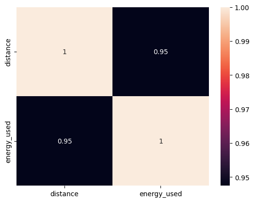

```python
sns.heatmap(distance_energy_used_correlation, annot=True)
```

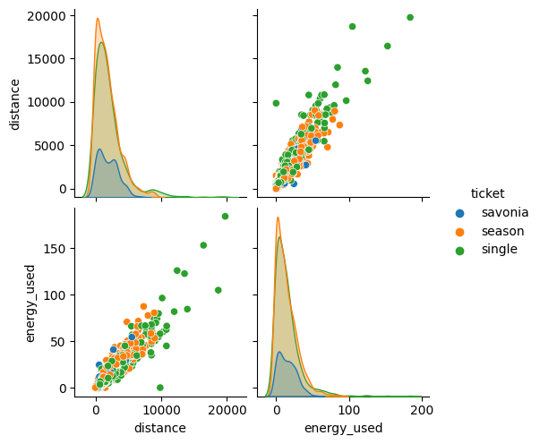

```python
sns.pairplot(DF.loc[DF.assistance == 1 , ['distance','energy_used','ticket']], hue='ticket')
```

**Both the variables are numeric and not normally distributed therefore, we choose spearman correlation. There is strong positive correlation between distance and energy consumed when electric assistance is enable.**

##### 6. Statistical evidence to claim that the savonia and season ticket types differ with respect to how often the trip ends where it started.

```python
savonia_season_contigency = pd.DataFrame({'savonia': savonia_ticket.loc[savonia_ticket.location_from == savonia_ticket.location_to, ['location_from']].value_counts(),
                                          'season': season_ticket.loc[season_ticket.location_from == season_ticket.location_to, ['location_from']].value_counts()})
```

```python
savonia_season_contigency
```

| location_from | savonia | season |
| --- | --- | --- |
| KYS | 3 | 20 |
| MICROTEKNIA | 25 | 23 |
| PETONEN | 2 | 27 |
| RYPYSUO | 3 | 14 |
| SATAMA | 6 | 57 |
| SNELLMANIA | 7 | 15 |
| TEATTERI | 0 | 28 |
| TORI | 30 | 153 |
| UIMAHALLI | 0 | 7 |
| VÄINÖLÄNNIEMI | 0 | 23 |

```python
stats.chi2_contingency(savonia_season_contigency)[1]
```

```
6.524752303520206e-10
```

##### **Steps**

- Check the variable type (categorical in this case).
- Next step is to compare the two groups using chi square test, as the two variables are categorical

**p-value of the chi square test (6.524752303520206e-10) < 0.05, therefore, there is statistically significant evidence to claim that the savonia and season ticket types are different with respect to how often the trip ends where it started.**

##### 7. Statistical evidence to claim that the travel time correlates with the average speed at which the trip is made

```python
DF['average_speed'] = DF.distance/DF.duration
```

```python
speed_duration_correlation = DF[['average_speed', 'duration']].corr(method="spearman")
speed_duration_correlation
```

|  | average_speed | duration |
| --- | --- | --- |
| average_speed | 1.000000 | 0.513126 |
| duration | 0.513126 | 1.000000 |

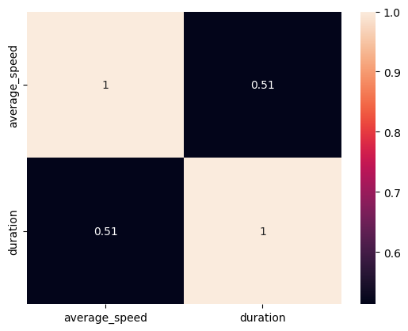

```python
sns.heatmap(speed_duration_correlation, annot=True)
```

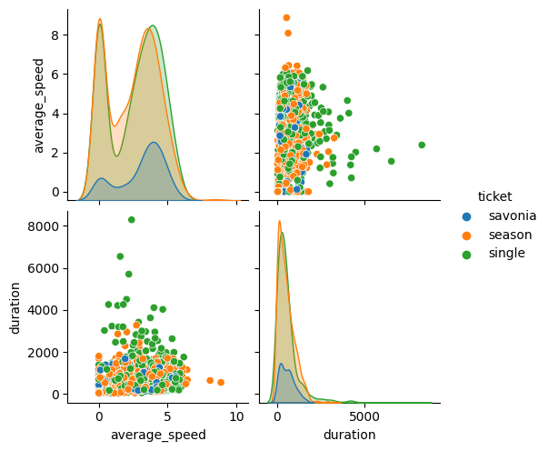

```python
sns.pairplot(DF[['average_speed', 'duration', 'ticket']], hue='ticket')
```

**Both the variables are numeric and not normally distributed therefore, we choose spearman correlation. There is moderate positive correlation between average_speed and duration.**